# Introduction and context

Media has emerged as a powerful source for information, influence, and entertainment. Content creators today can shape public opinion, create emotional responses, spread ideas, and affect consumer behavior. With hundreds of millions of posts every day flooding the web, understanding what makes content worth sharing is more critical than ever. We aim to determine content shareability indicators - from post timing and content category to the number of visuals and overall sentiment. These determinations can help newsmakers, digital marketers, and content managers improve their tactics and reach greater online audiences.

The dataset contains approximately 40,000 articles published by Mashable between January 2013 and January 2015. Mashable is a digital media and news platform known for covering technology, entertainment, and culture. As of November 2015, the outlet had over 6 million Twitter followers, highlighting its strong presence and influence on social media.

# Key takeways

## When do news articles get more shares (timing-wise)?

These plots show the effects of the day of the week an article is published and the category (“data channel”) the article is assigned to on the article’s shares. As evidenced by the first plot, we found significant differences in an article’s average number of shares on weekends versus weekdays. More specifically, an article published on Saturday or Sunday is likely to get significantly higher shares than if it was published on any weekday. However, articles assigned to the most popular categories, Social Media and Lifestyle, tend to get higher shares regardless of what day of the week they are published. We also found evidence that uncategorized articles receive significantly more shares on average than articles published in any other data channel, which is reflected in the second plot. These articles also tend to perform well regardless of what day of the week they are published. Given that there are about 6000 articles with no assigned category that make up 15% of all articles in the sample, other factors may have a greater influence on an article’s popularity than their publishing time and category.

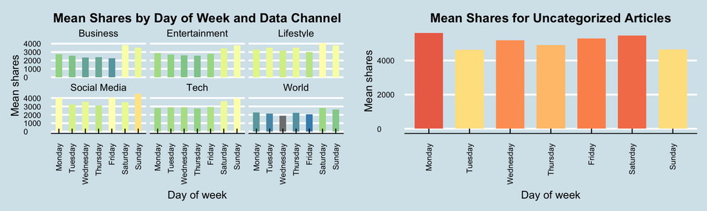

## What subject matter do people tend to share?

The graphs suggest that while both images and videos show a slight positive relationship with article shares, the effect is minimal, especially given how clustered the data is at low media counts. The first plot shows that articles with more images or videos tend to receive marginally more shares on average, but the trend lines are almost flat, indicating that media quantity alone doesn’t strongly drive popularity.

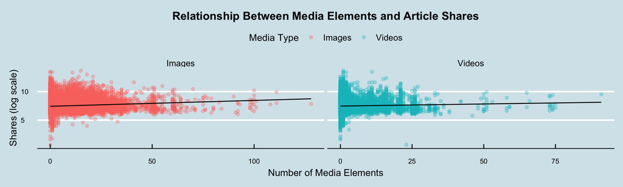

However, the second plot, which breaks down image counts by content category, reveals more nuanced patterns. For example, in the Business and World channels, articles with either no images or a high number of images (11+) tend to receive more shares, suggesting that users may prefer either streamlined content or richly visual stories in those domains. In contrast, other categories like Lifestyle or Entertainment show less variation across image bins. This indicates that subject matter and its interaction with media content can influence sharing behavior—certain audiences may respond differently to visual density depending on the topic. Additionally, we tested whether mean shares differ across the five image bins. Based on our testing, there is a statistically significant difference in mean shares across image bins, but the practical effect size may be small. This supports the idea that the number of images matters—but it’s likely just one of many factors influencing article popularity.

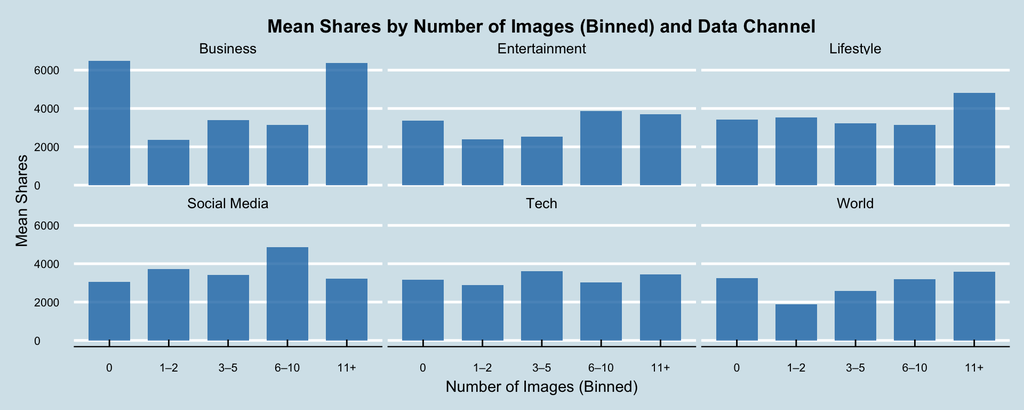

## What tone and perspective make articles more shareable?

The two scatterplots explore the relationship between the number of shares and two textual characteristics: subjectivity and title sentiment polarity. The left plot shows that articles with a moderate level of subjectivity receive more shares, with most data clustering around 0.5. Highly objective or subjective articles generally receive fewer shares, though a few outliers with very high share counts appear across the spectrum. The right plot, examining sentiment polarity in titles, reveals a similar trend: neutral sentiment (around 0.0) is associated with more shares, while extreme positive or negative sentiment has fewer virality peaks. Therefore, articles with moderate subjectivity and balanced title sentiment are likely to be widely shared, while strongly opinionated content is less predictably successful. To confirm these patterns, we ran a statistical test, which showed that both subjectivity and sentiment have a real impact on how much an article is shared. This means the trends hold true, because the chances of them happening by luck are low.

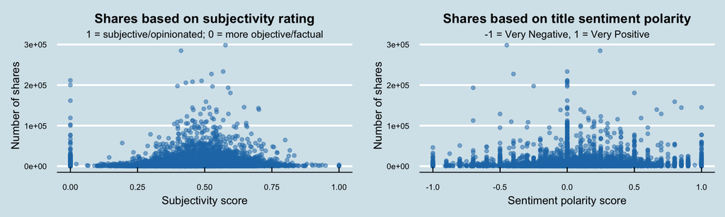

# Limitations

- Data is limited to Mashable articles between 2013 and 2015, which may not reflect current trends or generalize to other media platforms.
- Algorithms influence user reactions and sharing behavior, which may not fully capture genuine human responses.

# Implications